# Correlation Analysis on Measures of Credit/ Debit Cards

# Data Visualization and Analysis One by One

First of all, visualizing the big picture must be done one by one in order to identify measures of interest. Creating histograms for each year is a good way to start analyzing behavior before studying correlation with pairs.

## Credit and Debit Cards’ Transaction Volume

These histograms below include density of transaction volume with credit/debit cards. Note that 2015 has 9 monthly values and 2020 has 10 monthly values. These numbers state transaction in thousands of Turkish Liras. There are 15 bins in the x axis.

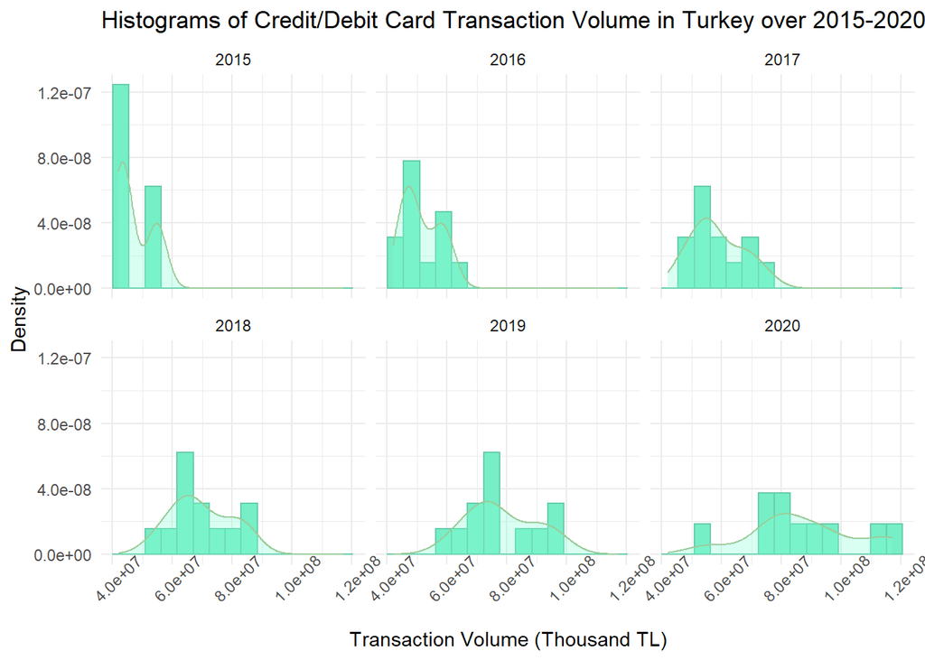

A brief glimpse is enough to say that the mean of transaction volume is increasing every year. This informs the reader about a trend line with positive slope. Also, variance of this measure is increasing every year, a normal-like distribution seems to have tendency to uniform-like distribution. These increments in variance can be caused by different increases in purchasing power in different social economic classes, or they are just a result of increasing variance of transactions. We cannot say anything about seasonality or cyclic structure from these histograms. It will be mentioned with plots of three measures below.

## Operation Amount with Credit and Debit Cards

These histograms below include number of operations with credit/debit cards. Note that 2015 has 9 monthly values and 2020 has 10 monthly values. There are 15 bins in the x axis.

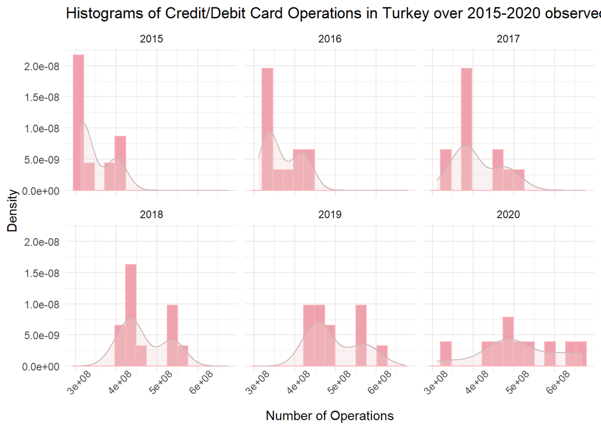

These histograms have similar behavior with the first ones. Not only mean but also variance is increasing over years. The difference between these two histogram sets is that operation amounts have more gaps between values compared to transaction volume. Parts of society may start using cards and cash in a more distinct ways.

## Credit Card Usage Index (April 2015 = 100)

These histograms below include credit card usage index in Turkey. Note that 2015 has 9 monthly values and 2020 has 10 monthly values. There are 10 bins in the x axis.

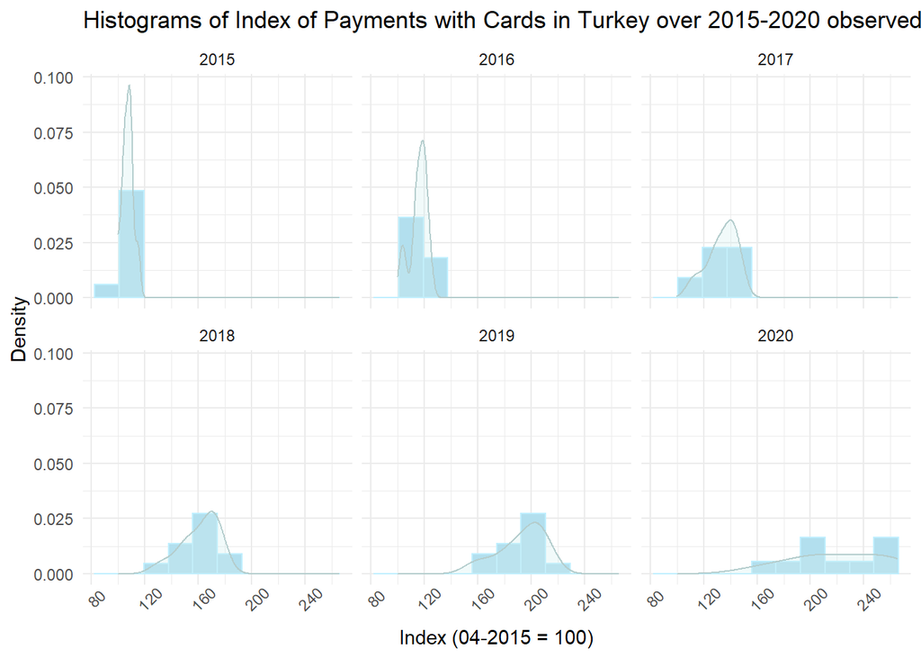

2015 does not give descriptive knowledge due to lack of data. These histograms of index show that credit card usage has never decreased compared to 04/2015 because all indices are greater than zero. If we look at the mean in 2019, we can say that usage of credit cards is duplicated in 4 years, and continues increasing. However, there is remarkable uniformity in 2020. This has made me think that some people change their payment behavior from cash to card whereas others do not.

# Visual Analysis Combining 3 Measures

## Boxplot of 3 Measures

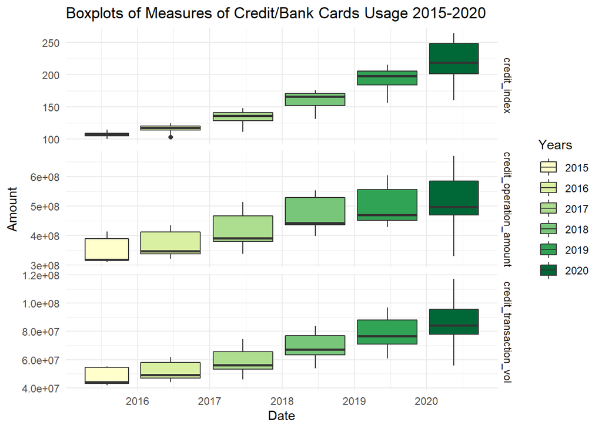

These boxplots give general knowledge about dissemination of 3 data sets. These increasing trends and variances over years mean that these 3 measures are highly correlated. Number of operations, transaction volumes, and usage indices have the highest variances respectively. The reader should keep in mind that scales are different for usage index, transaction volume, and number of operations. Indices range between 100-300, but number of operation is in millions, and transaction volumes in billions. For a detailed analysis, we should start examining values in a monthly manner.